# Análisis exploratorio: en_tx_canalX

Alejandro Bedoya - Sebastián Agudelo - Mateo Espinal - Juan Fernando Patiño - Estefanía Echeverry

Junio - 2021

# 1. Pasos previos al análisis

## 1.1. Se cargan las librerías necesarias

```r
library(dplyr)
library(knitr)
library(kableExtra)
library(ggplot2)
library(ggcorrplot)
library(scales)
library(formattable)
options(scipen = 999)
```

## 1.2. Lectura de la base de datos

```r
#Se carga la base de datos
datos_originales <- read.csv("../datos/base_trabajo_segmentacion.csv",
                             sep = ";")

#Se imprime la cabecera
kable(head(datos_originales), "html", align = "c") %>%
    kable_paper("hover", full_width = F) %>%
    row_spec(0, background = "#327CCF", color = "white")%>%
    scroll_box(width = "100%") %>%
    kable_styling(bootstrap_options = c("hover", "condensed"))
```

| nit | en_vm_canal1 | en_vm_canal2 | en_vm_canal3 | en_vm_canal4 | en_vm_canal5 | en_vm_canal6 | en_vm_canal7 | en_vm_canal8 | en_vm_canal9 | en_vm_canal10 | en_vm_otros | en_tx_canal1 | en_tx_canal2 | en_tx_canal3 | en_tx_canal4 | en_tx_canal5 | en_tx_canal6 | en_tx_canal7 | en_tx_canal8 | en_tx_canal9 | en_tx_canal10 | en_tx_otros | sal_vm_canal5 | sal_vm_canal2 | sal_vm_canal8 | sal_vm_otros | sal_tx_canal5 | sal_tx_canal2 | sal_tx_canal8 | … |
| --- | --- | --- | --- | --- | --- | --- | --- | --- | --- | --- | --- | --- | --- | --- | --- | --- | --- | --- | --- | --- | --- | --- | --- | --- | --- | --- | --- | --- | --- | --- |
| C4936394968152386565 | 0 | 0 | 0 | 0 | 0 | 0 | 0 | 0 | 0 | 0 | 0 | 0.000000 | 0.000000 | 0.000000 | 0.00000 | 0.000000 | 0.00 | 0.00 | 0.0 | 0 | 0 | 0 | 0 | 0 | 0 | 0 | 0.000000 | 0.00000 | 0 | … |
| C-8615176103348111575 | 0 | 0 | 0 | 0 | 0 | 0 | 0 | 0 | 0 | 0 | 0 | 0.000000 | 0.000000 | 0.000000 | 0.00000 | 0.000000 | 0.00 | 0.00 | 0.0 | 0 | 0 | 0 | 0 | 0 | 0 | 0 | 0.000000 | 0.00000 | 0 | … |
| C2364605246729357060 | 250927493 | 54160892 | 5122152 | 41852510 | 413614315 | 1663236 | 2106847525 | 0 | 0 | 0 | 0 | 24.416667 | 11.916667 | 3.333333 | 237.83333 | 2.545454 | 5.40 | 8.25 | 0.0 | 0 | 0 | 0 | 413614315 | 2265361194 | 0 | 0 | 2.545454 | 613.08333 | 0 | … |
| C7393816976826597531 | 39402360 | 96468998 | 8226710 | 0 | 0 | 7072802 | 0 | 9000000 | 0 | 0 | 0 | 14.416667 | 13.833333 | 4.600000 | 0.00000 | 0.000000 | 2.80 | 0.00 | 1.0 | 0 | 0 | 0 | 0 | 60558440 | 0 | 0 | 0.000000 | 10.33333 | 0 | … |
| C872645851723947566 | 337432319 | 234217927 | 105344054 | 15755287 | 0 | 23671840 | 0 | 3600962 | 3727299 | 0 | 0 | 153.583333 | 42.250000 | 102.416667 | 49.33333 | 0.000000 | 18.00 | 0.00 | 2.2 | 4 | 0 | 0 | 0 | 0 | 0 | 622080714 | 0.000000 | 0.00000 | 0 | … |
| C-3870380727390720970 | 33629514 | 42883291 | 1348792 | 0 | 0 | 3828360 | 0 | 0 | 687244 | 0 | 0 | 7.416667 | 8.833333 | 1.000000 | 0.00000 | 0.000000 | 1.25 | 0.00 | 0.0 | 1 | 0 | 0 | 0 | 1960611436 | 0 | 0 | 0.000000 | 90.00000 | 0 | … |

## 1.3. Creación de funciones necesarias

**Función encargada de presentar los resúmenes numéricos**

```r
#Se define la función para presentar los resumenes numéricos
resumen <- function(columna){
    #Se usa la función summary para encontrar los resumenes
    summary_canal <- summary(columna)

    #Se convierte a array y se transpone el resumen numérico
    summary_canal <- t(summary_canal)

    #Se crea el fomato numérico para los datos
    numerico <- dollar_format(prefix = "")

    #Se añade separador de miles a las cantidades
    summary_canal <- t(apply(summary_canal, 2, numerico))

    #Se calcula la cantidad de ceros de la variable
    ceros <- sum(columna == 0)

    #Se calcula la proporción de ceros para cada variable
    prop_ceros <- ceros/length(columna)

    #Se convierte la proporción de ceros a escala de porcentaje
    prop_ceros <- round(prop_ceros,4)*100

    #Se añade el simbolo de porcentaje a la proporción de eros
    prop_ceros <- paste0(prop_ceros,"%")

    #Se concatena el resumen numerico con la cantidad y la proporción de ceros
    summary_canal <- cbind(summary_canal, ceros, prop_ceros)

    #Se crean los nombres en español para los resumenes
    nombres_resumen <- c("Mínimo", "Q1", "Mediana", "Media", "Q3",
                         "Máximo", "Ceros", "Proporcion ceros")

    #Se estiliza el resumen con la función kable
    kable(summary_canal, col.names = nombres_resumen, align = "c",  "html") %>%
        #Se utiliza el tema kable_papper
        kable_paper("hover", full_width = TRUE) %>%
        kable_styling(bootstrap_options = c("hover", "condensed"),
                      font_size = 16) %>%
        row_spec(0, background = "#327CCF", color = "white")
}
```

**Función encargada de realizar los histogramas**

```r
#Se crea la función para dibujar los gráficos
crear_grafico <- function(datos, columna, bins=300, numero_columna){

    columna = enquo(columna)

    #Se crea el histograma
    grafico <- ggplot(datos, aes(x = !!columna)) +
        geom_histogram(bins = bins, fill="#327CCF", alpha = 0.4, col = "Black")+
        #Se añade la etiqueta del eje x
        xlab(
            paste("Transacciones promedio de entrada por el canal",
                  numero_columna)
        ) +
        #Se añade la etiqueta del eje y
        ylab("Frecuencia") +
        #Se añade la etiqueta del titulo
        ggtitle(
            paste(
              "Histograma del número de transacciones promedio de entrada por el canal",
              numero_columna)
        ) +
        theme_bw()+
        #Se centra el titulo
        theme(plot.title = element_text(hjust = 0.5))

    return(grafico)
}
```

# 2. Análisis de las variables `en_tx_canalx`

## 2.1. `en_tx_canal1`

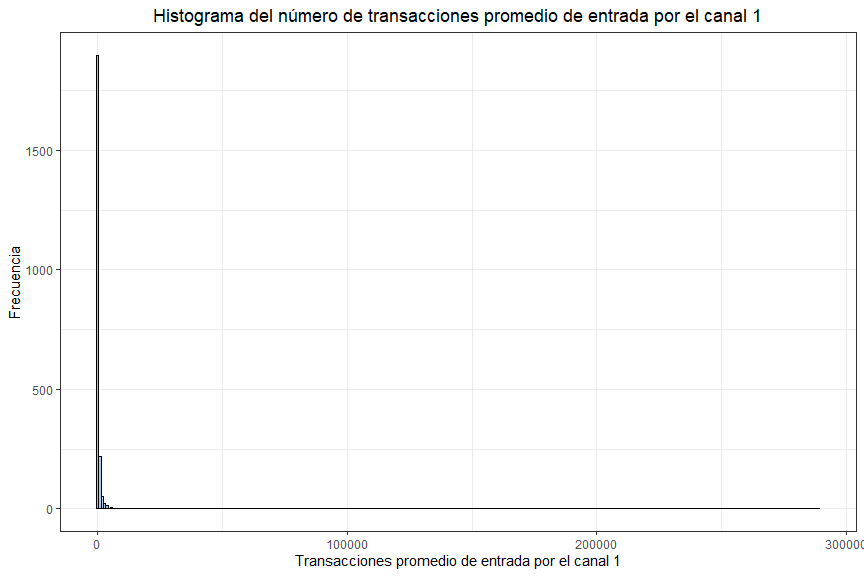

```r
crear_grafico(datos_originales, en_tx_canal1, bins = 320, numero_columna = 1)
```

```r
resumen(datos_originales$en_tx_canal1)
```

| Mínimo | Q1 | Mediana | Media | Q3 | Máximo | Ceros | Proporcion ceros |
| --- | --- | --- | --- | --- | --- | --- | --- |
| 0 | 4.67 | 48.08 | 622.49 | 235.92 | 289,252 | 202 | 9.05% |

Del histograma se resalta que la distribución del número de transacciones promedio de entrada por el canal 1 se encuentra altamente sesgada a la derecha, lo cual se refleja en el resumen numérico donde la media (622.49) es aproximadamente 13 veces mayor a la mediana (48.08) y al rededor de 2.64 veces mayor al cuartil 3 (235.92), indicando la presencia de máximos muy altos.

Se destaca además que la proporción de entradas en cero (9.05%) del canal es baja, lo cual indica que es concurrido y da la sensación de tener pocas restricciones, ser de fácil acceso y presentar una cantidad alta en el número transacciones realizadas.

## 2.2. `en_tx_canal2`

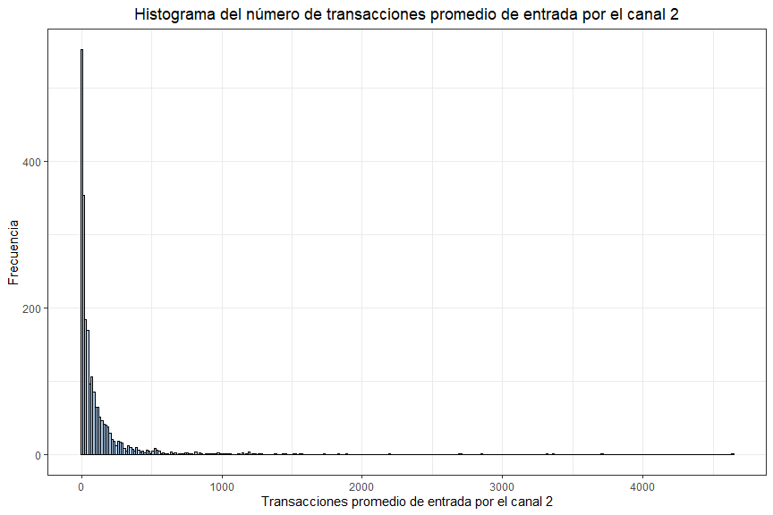

```r
crear_grafico(datos_originales, en_tx_canal2, bins = 320, numero_columna = 2)
```

```r
resumen(datos_originales$en_tx_canal2)
```

| Mínimo | Q1 | Mediana | Media | Q3 | Máximo | Ceros | Proporcion ceros |
| --- | --- | --- | --- | --- | --- | --- | --- |
| 0 | 7.58 | 38.25 | 122.01 | 122.83 | 4,638.83 | 186 | 8.33% |

Del histograma se resalta que la distribución del número de transacciones promedio de entrada por el canal 2 se encuentra sesgada a la derecha, lo cual se refleja en el resumen numérico donde la media (122.01) es aproximadamente 3.19 veces mayor a la mediana (38.25) y muy similar al cuartil 3 (122.83), indicando la presencia de máximos altos.

Se destaca además que la proporción de entradas en cero (8.33%) es levemente mas baja que lo observado en el canal 1, lo cual indica analogamente que es un canal concurrido, da la sensación de tener pocas restricciones y ser de fácil acceso, presentando una cantidad moderadamente alta en el número transacciones realizadas.

## 2.3. `en_tx_canal3`

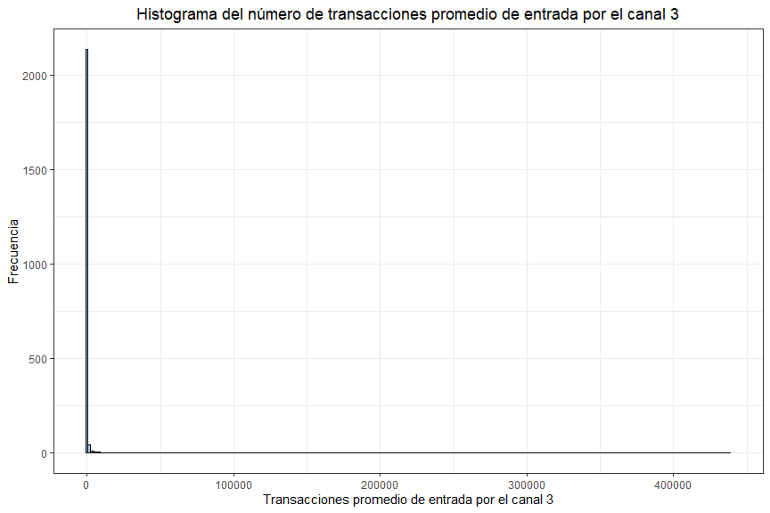

```r
crear_grafico(datos_originales, en_tx_canal3, bins = 320, numero_columna = 3)
```

```r
resumen(datos_originales$en_tx_canal3)
```

| Mínimo | Q1 | Mediana | Media | Q3 | Máximo | Ceros | Proporcion ceros |
| --- | --- | --- | --- | --- | --- | --- | --- |
| 0 | 0 | 1.88 | 863.61 | 8.83 | 438,620 | 705 | 31.57% |

Del histograma se resalta que la distribución del número de transacciones promedio de entrada por el canal 3 se encuentra altamente sesgada a la derecha, lo cual se refleja en el resumen numérico donde la media (863.61) es aproximadamente 461 veces mayor a la mediana (1.88) y al rededor de 97.77 veces mayor al cuartil 3 (8.83).

Al tener en cuenta lo anterior y observando que la proporción de entradas en cero (31.57%) es moderadamente alta, se intuye que es un canal con una concurrencia medianamente alta y con grandes valores en el número transacciones realizadas.

## 2.4. `en_tx_canal4`

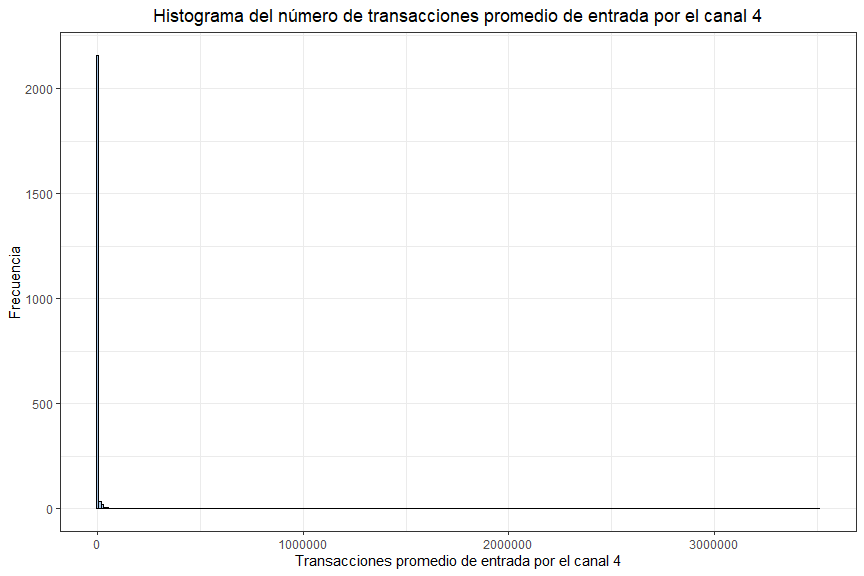

```r
crear_grafico(datos_originales, en_tx_canal4, bins = 320, numero_columna = 4)
```

```r
resumen(datos_originales$en_tx_canal4)
```

| Mínimo | Q1 | Mediana | Media | Q3 | Máximo | Ceros | Proporcion ceros |
| --- | --- | --- | --- | --- | --- | --- | --- |
| 0 | 0 | 0 | 2,623.65 | 5.91 | 3,510,700 | 1591 | 71.25% |

Del histograma se resalta que la distribución del número de transacciones promedio de entrada por el canal 4 se encuentra altamente sesgada a la derecha, lo cual se refleja en el resumen numérico donde la mediana (0) es cero y el cuartil 3 (5.91) presenta un valor muy bajo, adicionalmete la proporción de entradas en cero (71.25%) es sumamente alta. Sin embargo, el valor máximo (3,510,700) es el más alto de las variables de este tipo, influenciando en gran medida a la media (2,623.65).

Lo anterior nos presenta el panorama de una canal con un uso moderadamente bajo y con enormes valores en el número de transacciones realizadas, por lo cual se intuye que podría ser un canal popular para un tipo especifico de transacción o exclusivo para determinados empresas.

## 2.5. `en_tx_canal5`

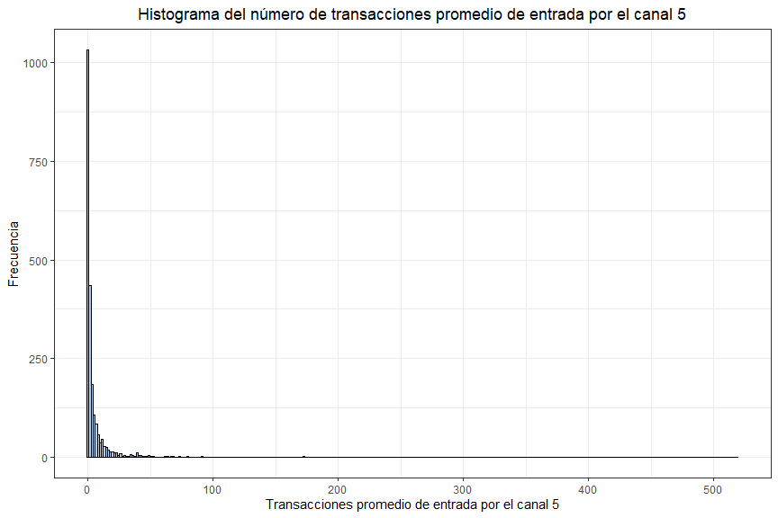

```r
crear_grafico(datos_originales, en_tx_canal5, bins = 320, numero_columna = 5)
```

```r
resumen(datos_originales$en_tx_canal5)
```

| Mínimo | Q1 | Mediana | Media | Q3 | Máximo | Ceros | Proporcion ceros |
| --- | --- | --- | --- | --- | --- | --- | --- |
| 0 | 0 | 1 | 5.70 | 4.36 | 519.17 | 1032 | 46.22% |

Del histograma se resalta que la distribución del número de transacciones promedio de entrada por el canal 5 se encuentra sesgada a la derecha, lo cual se refleja en el resumen numérico donde la media (5.70) es mayor a la mediana (1) y levemente mayor al cuartil 3 (4.36), indicando la presencia de máximos moderadamente bajos en comparación con las variables anteriores.

Se destaca además que la proporción de entradas en cero (46.22%) es muy cercana al 50%, indicando que se puede tratar de un canal de uso medio, con números bajos en la cantidad de transacciones, dando la sensación de ser medianamente restrictivo.

## 2.6. `en_tx_canal6`

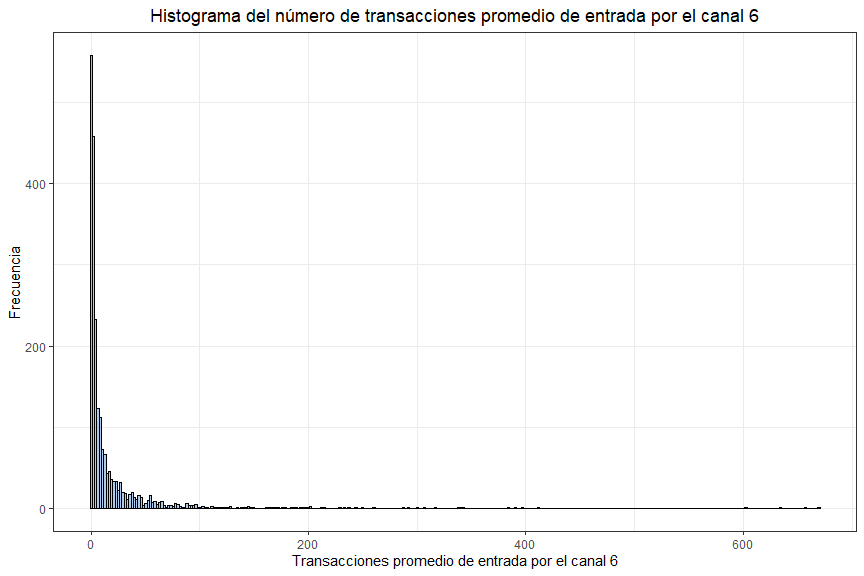

```r
crear_grafico(datos_originales, en_tx_canal6, bins = 320, numero_columna = 6)
```

```r
resumen(datos_originales$en_tx_canal6)
```

| Mínimo | Q1 | Mediana | Media | Q3 | Máximo | Ceros | Proporcion ceros |
| --- | --- | --- | --- | --- | --- | --- | --- |
| 0 | 1.08 | 3.89 | 18.89 | 16 | 669.67 | 426 | 19.08% |

Del histograma se resalta que la distribución del número de transacciones promedio de entrada por el canal 6 se encuentra sesgada a la derecha, lo cual se refleja en el resumen numérico donde la media (18.89) es mayor a la mediana (3.89) y levemente mayor al cuartil 3 (16), indicando la presencia de máximos moderadamente bajos.

Se destaca además que la proporción de entradas en cero (19.08%) es moderadamente baja, indicando que se puede tratar de un canal de un uso alto, dando la sensación de no ser muy restrictivo y popular para realizar un numero bajo de transacciones.

## 2.7. `en_tx_canal7`

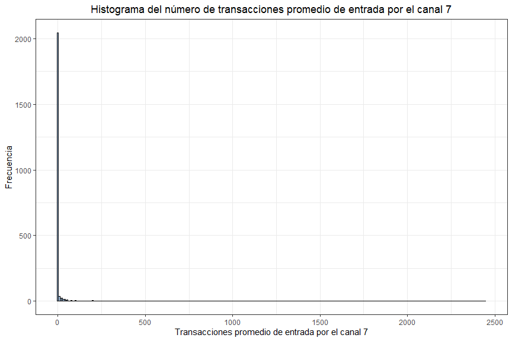

```r
crear_grafico(datos_originales, en_tx_canal7, bins = 320, numero_columna = 7)
```

```r
resumen(datos_originales$en_tx_canal7)
```

| Mínimo | Q1 | Mediana | Media | Q3 | Máximo | Ceros | Proporcion ceros |
| --- | --- | --- | --- | --- | --- | --- | --- |
| 0 | 0 | 0 | 7.82 | 0 | 2,446.50 | 2028 | 90.82% |

Del histograma se resalta que la distribución del número de transacciones promedio de entrada por el canal 7 se encuentra altamente sesgada a la derecha, lo cual se refleja en el resumen numérico donde la mediana (0) es cero, al igual que el cuartil 3 (0), adicionalmete la proporción de entradas en cero (90.82%) es demasiado alta, lo cual se refleja en el valor de la media (7.82).

Lo anterior nos presenta el panorama de un canal de poco uso, con valores moderadamente bajos en el número de transacciones realizadas, por lo cual se intuye que podría estar dedicado para un tipo muy especifico de transacción o ser exclusivo para determinados clientes.

## 2.8. `en_tx_canal8`

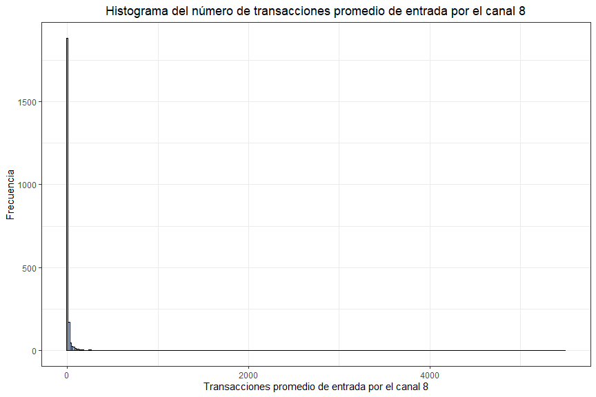

```r
crear_grafico(datos_originales, en_tx_canal8, bins = 320, numero_columna = 8)
```

```r
resumen(datos_originales$en_tx_canal8)
```

| Mínimo | Q1 | Mediana | Media | Q3 | Máximo | Ceros | Proporcion ceros |
| --- | --- | --- | --- | --- | --- | --- | --- |
| 0 | 0 | 1.33 | 20.84 | 3.83 | 5,492.67 | 723 | 32.38% |

Del histograma se resalta que la distribución del número de transacciones promedio de entrada por el canal 8 se encuentra altamente sesgada a la derecha, con un comportamiento muy similar a lo evidenciado en el canal 3, donde la media (20.84) es mayor a la mediana (1.33) y al cuartil 3 (3.83).

Al tener en cuenta lo anterior y observando que la proporción de entradas en cero (32.38%) es moderadamente alta y levemente mayor al resultado del canal 3, se intuye que cuenta con una concurrencia medianamente alta y valores moderadamente bajos en el número transacciones realizadas.

## 2.9. `en_tx_canal9`

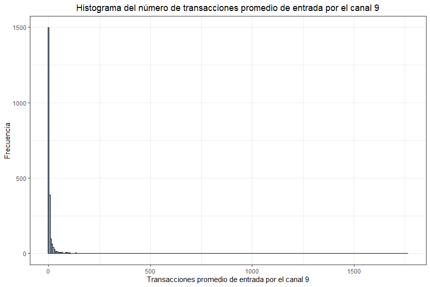

```r
crear_grafico(datos_originales, en_tx_canal9, bins = 320, numero_columna = 9)
```

```r
resumen(datos_originales$en_tx_canal9)
```

| Mínimo | Q1 | Mediana | Media | Q3 | Máximo | Ceros | Proporcion ceros |
| --- | --- | --- | --- | --- | --- | --- | --- |
| 0 | 0 | 1.50 | 10.55 | 4.22 | 1,763.78 | 727 | 32.56% |

Del histograma se resalta que la distribución del número de transacciones promedio de entrada por el canal 9 se encuentra altamente sesgada a la derecha, donde la media (10.55) es mayor a la mediana (1.50) y al cuartil 3 (4.22).

Al tener en cuenta lo anterior y observando que la proporción de entradas en cero (32.56%) es muy similar al resultado del canal 8, se intuye que es un canal con una concurrencia medianamente alta y valores moderadamente bajos en el número transacciones realizadas, siendo en promedio mas bajos que los evidenciados en el canal anterior.

## 2.10. `en_tx_canal10`

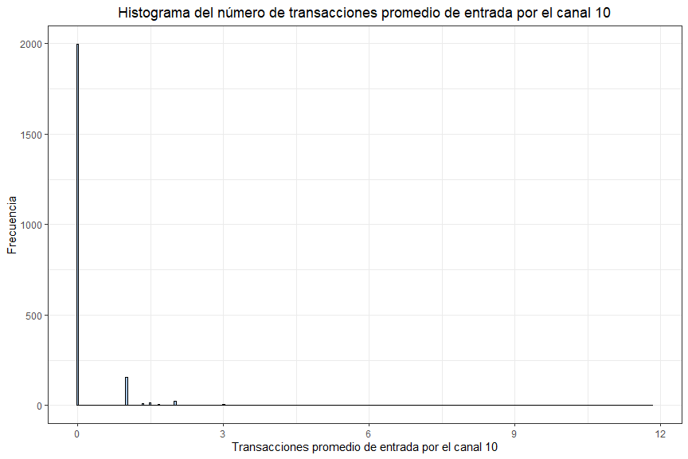

```r
crear_grafico(datos_originales, en_tx_canal10, bins = 320, numero_columna = 10)
```

```r
resumen(datos_originales$en_tx_canal10)
```

| Mínimo | Q1 | Mediana | Media | Q3 | Máximo | Ceros | Proporcion ceros |
| --- | --- | --- | --- | --- | --- | --- | --- |
| 0 | 0 | 0 | 0.16 | 0 | 11.83 | 1998 | 89.48% |

Del histograma se resalta que la distribución del número de transacciones promedio de entrada por el canal 10 se encuentra altamente sesgada a la derecha, lo cual se refleja en el resumen numérico donde la mediana (0) es cero, al igual que el cuartil 3 (0), por su parte la proporción de entradas en cero (89.48%) es demasiado alta, lo cual se refleja en el valor de la media (0.16), siendo esta ultima medida menor a 1.

Lo anterior nos presenta el panorama de un canal de poco uso y con valores supremamente bajos en el número de transacciones realizadas, por lo cual se intuye que podría estar dedicado para un tipo muy especifico de transacción, ser de difícil acceso, restrictivo o exclusivo para empresas con un muy bajo numero de transacciones.

## 2.11. `en_tx_otros`

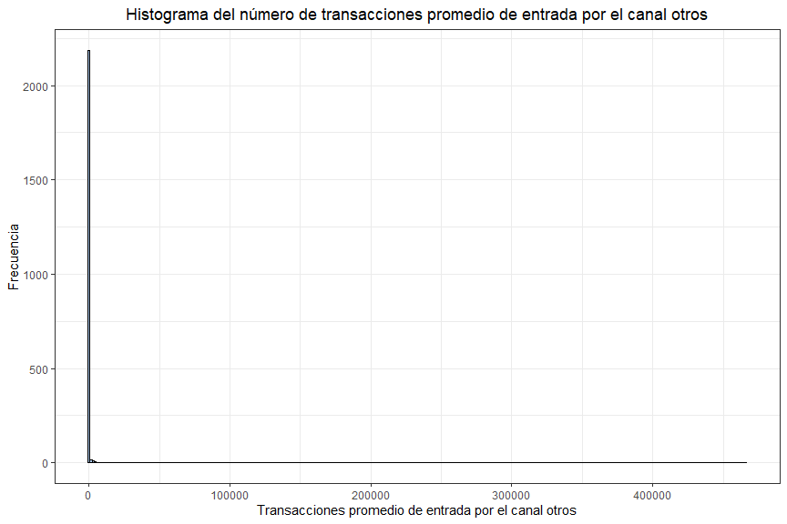

```r
crear_grafico(datos_originales, en_tx_otros, bins = 320, numero_columna = "otros")
```

```r
resumen(datos_originales$en_tx_otros)
```

| Mínimo | Q1 | Mediana | Media | Q3 | Máximo | Ceros | Proporcion ceros |
| --- | --- | --- | --- | --- | --- | --- | --- |
| 0 | 0 | 0 | 670.00 | 0 | 466,385 | 1829 | 81.91% |

Del histograma se resalta que la distribución del número de transacciones promedio de entrada por el canal otros se encuentra altamente sesgada a la derecha, lo cual se refleja en el resumen numérico donde la mediana (0) es cero, al igual que el cuartil 3 (0), por su parte proporción de entradas en cero (81.91%) es muy grande, sin embargo la media (670.00) conserva un valor moderadamente alto, destacando la influencia de los valores máximos.

Lo anterior nos presenta el panorama de una canal con un uso bajo y con valores moderadamente altos en el número de transacciones realizadas, por lo cual se intuye que podría estar dedicado para un tipo muy especifico de transacción o ser exclusivo para determinadas empresas.

# 3. Tabla general de resumenes numéricos

```r
#Se seleccionan las columnas de tipo en_tx
datos_en_tx <- datos_originales %>% select(contains("en_tx"))

#Se aplica la función summary a cada columna
resumen_general <- t(apply(datos_en_tx, 2, function(x){summary(x)}))

#Se convierte el resulado anterior a data frame
resumen_general <- as.data.frame(resumen_general)

#Se crea el formato numerico para los datos
numerico <- dollar_format(prefix = "")

#Se convierten las cantidades a formato numerico
resumen_general <- apply(resumen_general, 2, numerico)

#Se calcula la cantidad de ceros para cada variable
cantidad_ceros <- apply(datos_en_tx, 2, function(x){sum(x==0)})

#Se calcula la proporción de ceros para cada variable
proporcion_ceros <- apply(datos_en_tx,
                          2,
                          function(x){
                            p_ceros <- sum(x==0)/length(x)
                            p_ceros <- round(p_ceros ,4)*100
                            paste0(p_ceros, "%")
                            }
                          )

#Se concatene el resumen con la cantidad y la proporción de ceros
resumen_general <- cbind(resumen_general, cantidad_ceros, proporcion_ceros)

#Se crean las etiquetas de la cabecera para los resumenes
nombres_resumen <- c(
  "Mínimo", "Q1", "Mediana", "Media", "Q3", "Máximo", "Ceros", "Proporcion ceros"
  )

#Se muestra la tabla estilizada con la función kable
kable(resumen_general, col.names = nombres_resumen, align = "r") %>%
    kable_paper("hover", full_width = TRUE) %>%
    kable_styling(bootstrap_options = c("hover", "condensed"), font_size = 14) %>%
    row_spec(0, background = "#327CCF", color = "white")
```

|  | Mínimo | Q1 | Mediana | Media | Q3 | Máximo | Ceros | Proporcion ceros |
| --- | --- | --- | --- | --- | --- | --- | --- | --- |
| en_tx_canal1 | 0 | 4.67 | 48.08 | 622.49 | 235.92 | 289,252 | 202 | 9.05% |
| en_tx_canal2 | 0 | 7.58 | 38.25 | 122.01 | 122.83 | 4,639 | 186 | 8.33% |
| en_tx_canal3 | 0 | 0.00 | 1.88 | 863.61 | 8.83 | 438,620 | 705 | 31.57% |
| en_tx_canal4 | 0 | 0.00 | 0.00 | 2,623.65 | 5.91 | 3,510,700 | 1591 | 71.25% |
| en_tx_canal5 | 0 | 0.00 | 1.00 | 5.70 | 4.36 | 519 | 1032 | 46.22% |
| en_tx_canal6 | 0 | 1.08 | 3.89 | 18.89 | 16.00 | 670 | 426 | 19.08% |
| en_tx_canal7 | 0 | 0.00 | 0.00 | 7.82 | 0.00 | 2,446 | 2028 | 90.82% |
| en_tx_canal8 | 0 | 0.00 | 1.33 | 20.84 | 3.83 | 5,493 | 723 | 32.38% |
| en_tx_canal9 | 0 | 0.00 | 1.50 | 10.55 | 4.22 | 1,764 | 727 | 32.56% |
| en_tx_canal10 | 0 | 0.00 | 0.00 | 0.16 | 0.00 | 12 | 1998 | 89.48% |
| en_tx_otros | 0 | 0.00 | 0.00 | 670.00 | 0.00 | 466,385 | 1829 | 81.91% |

# 4. Correlación entre las variables

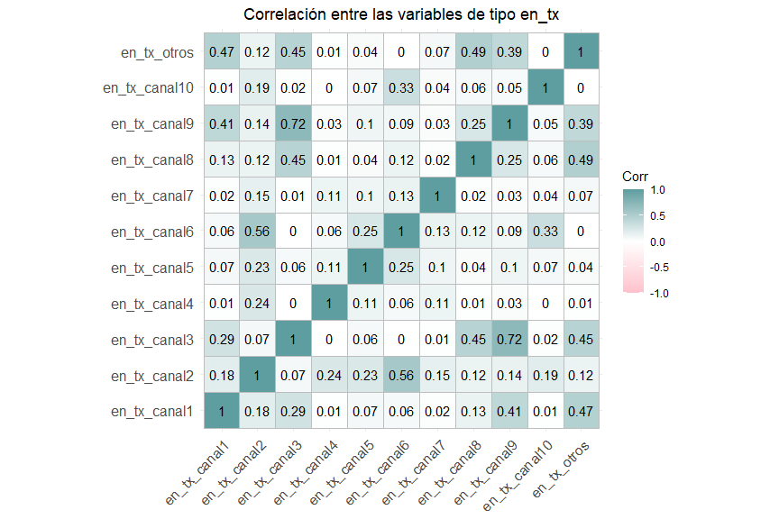

```r
#Se calulan las correlaciones entre las variables
correlaciones <- cor(datos_en_tx)

#Se muestra el gráfico de correlación
ggcorrplot(correlaciones, lab = TRUE, colors = c("pink",
                                                 "white",
                                                 "cadetblue")
)+
  #Se añade el titulo del gráfico
  ggtitle("Correlación entre las variables de tipo en_tx")+
  #Se centra el titulo
  theme(plot.title = element_text(hjust = 0.5))
```